# Reproducible Research Week 2 Assignment

Kunal Sharma

01/03/2020

## Set up code for working directory and markdown settings

```r
getwd()
dir()
setwd("~/R/ReproducibleWeek2Assignment")
knitr::opts_chunk$set(echo = TRUE)
```

## 1a) Load data and explore layout

The following code is intended to read in the activity data, and get a feel for the layout of the dataset.

```r
activity.data <- read.table("activity.csv", sep=",", header=TRUE)

ncol(activity.data)
```

```
## [1] 3
```

```r
nrow(activity.data)
```

```
## [1] 17568
```

```r
names(activity.data)    # names of columns are "steps", "date" and "interval"
```

```
## [1] "steps"    "date"     "interval"
```

```r
head(activity.data)
```

```
##   steps       date interval
## 1    NA 2012-10-01        0
## 2    NA 2012-10-01        5
## 3    NA 2012-10-01       10
## 4    NA 2012-10-01       15
## 5    NA 2012-10-01       20
## 6    NA 2012-10-01       25
```

```r
summary(activity.data$steps)
```

```
##    Min. 1st Qu.  Median    Mean 3rd Qu.    Max.    NA's
##    0.00    0.00    0.00   37.38   12.00  806.00    2304
```

```r
summary(activity.data$date)      # shows that the dates are shown as factors
```

```
## 2012-10-01 2012-10-02 2012-10-03 2012-10-04 2012-10-05 2012-10-06
##        288        288        288        288        288        288
## 2012-10-07 2012-10-08 2012-10-09 2012-10-10 2012-10-11 2012-10-12
##        288        288        288        288        288        288
## 2012-10-13 2012-10-14 2012-10-15 2012-10-16 2012-10-17 2012-10-18
##        288        288        288        288        288        288
## 2012-10-19 2012-10-20 2012-10-21 2012-10-22 2012-10-23 2012-10-24
##        288        288        288        288        288        288
## 2012-10-25 2012-10-26 2012-10-27 2012-10-28 2012-10-29 2012-10-30
##        288        288        288        288        288        288
## 2012-10-31 2012-11-01 2012-11-02 2012-11-03 2012-11-04 2012-11-05
##        288        288        288        288        288        288
## 2012-11-06 2012-11-07 2012-11-08 2012-11-09 2012-11-10 2012-11-11
##        288        288        288        288        288        288
## 2012-11-12 2012-11-13 2012-11-14 2012-11-15 2012-11-16 2012-11-17
##        288        288        288        288        288        288
## 2012-11-18 2012-11-19 2012-11-20 2012-11-21 2012-11-22 2012-11-23
##        288        288        288        288        288        288
## 2012-11-24 2012-11-25 2012-11-26 2012-11-27 2012-11-28 2012-11-29
##        288        288        288        288        288        288
## 2012-11-30
##        288
```

```r
summary(activity.data$interval)
```

```
##    Min. 1st Qu.  Median    Mean 3rd Qu.    Max.
##     0.0   588.8  1177.5  1177.5  1766.2  2355.0
```

## 1b) Processing data

The code below converts the “date” column entries into a date format with which the analysis is more workable.

```r
library("lubridate")
activity.data$date <- ymd(activity.data$date)
summary(activity.data$date)                       # shows that the dates are no longer factors
```

```
##         Min.      1st Qu.       Median         Mean      3rd Qu.
## "2012-10-01" "2012-10-16" "2012-10-31" "2012-10-31" "2012-11-15"
##         Max.
## "2012-11-30"
```

## 2) Histogram of the total number of steps taken each day

The code below plots a histogram for the total number of steps taken on each day, across all time intervals.

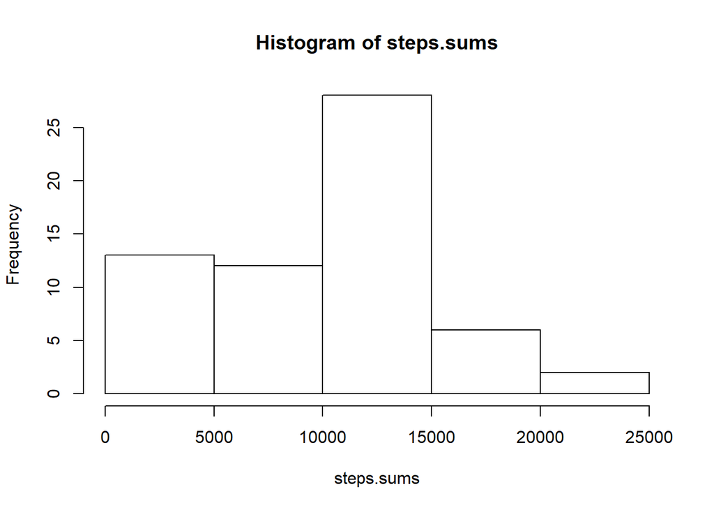

```r
sum.na <- function(x){sum(x, na.rm=TRUE)}
steps.sums <- tapply(activity.data$steps, activity.data$date, FUN=sum.na)
hist(steps.sums)
```

## 3) Mean and median number of steps each day

```r
mean1 <- mean(steps.sums)    # note that this includes those days with zero (all NA) steps
median1 <- median(steps.sums)  # note that this includes those days with zero (all NA) steps
mean1
```

```
## [1] 9354.23
```

```r
median1
```

```
## [1] 10395
```

The code above shows that the mean number of steps taken each day is 9354.2295082 and the median number of steps is 10395.

## 4) Time series plot of the average number of steps in each interval

The code below plots a time series for the average number of steps taken within each time interval, across all days.

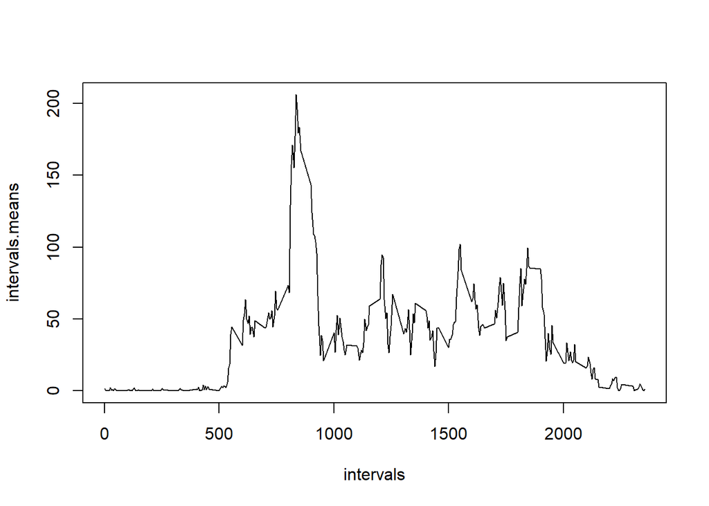

```r
average.na <- function(x){mean(x, na.rm=TRUE)}

intervals.means <- tapply(activity.data$steps, activity.data$interval, FUN=average.na)
intervals <- tapply(activity.data$interval, activity.data$interval, FUN=average.na)

plot(intervals, intervals.means, type="l")
```

## 5) Time interval with highest average steps

```r
interval <- intervals[intervals.means==max(intervals.means)]
maximum <- max(intervals.means)
interval
```

```
## 835
## 835
```

```r
maximum
```

```
## [1] 206.1698
```

The code above shows that the time interval with the highest average number of steps, across all days, is 835 with 206.1698113 average steps.

## 6) Imputing missing data

```r
   summary(activity.data$steps)     # shows 2304 NAs in this variable
```

```
##    Min. 1st Qu.  Median    Mean 3rd Qu.    Max.    NA's
##    0.00    0.00    0.00   37.38   12.00  806.00    2304
```

```r
   summary(activity.data$date)      # shows no NAs in this variable
```

```
##         Min.      1st Qu.       Median         Mean      3rd Qu.
## "2012-10-01" "2012-10-16" "2012-10-31" "2012-10-31" "2012-11-15"
##         Max.
## "2012-11-30"
```

```r
   summary(activity.data$interval)  # shows no NAs in this variable
```

```
##    Min. 1st Qu.  Median    Mean 3rd Qu.    Max.
##     0.0   588.8  1177.5  1177.5  1766.2  2355.0
```

```r
   na.data <- data.frame(intervals)
   na.data[,2] <- intervals.means

   activity.data.na <- activity.data  # create a copy of the data set, in which to carry out the imputation

   for(i in 1:17568){
      if(is.na(activity.data.na$steps[i])){
         activity.data.na$steps[i]<-na.data[na.data[,1]==activity.data.na$interval[i],2]
      }
      else(activity.data.na$steps[i]<-activity.data.na$steps[i])  # the function replaces NA values with an average value
   }
```

The code above is designed to replace NA values within the dataset with the average value, across all days, for the time interval being considered.

The code above also shows that only the “steps” variable within the data has NA values, and the code below shows that the imputed dataset no longer has such NA values.

```r
   summary(activity.data.na$steps)
```

```
##    Min. 1st Qu.  Median    Mean 3rd Qu.    Max.
##    0.00    0.00    0.00   37.38   27.00  806.00
```

## 7) Histogram of the total number of steps taken each day (imputed data)

The code below plots a histogram for the total number of steps taken on each day, across all time intervals, using the newly-imputed data.

```r
steps.sums.na <- tapply(activity.data.na$steps, activity.data.na$date, FUN=sum.na)
steps.sums.na
```

```
## 2012-10-01 2012-10-02 2012-10-03 2012-10-04 2012-10-05 2012-10-06
##   10766.19     126.00   11352.00   12116.00   13294.00   15420.00
## 2012-10-07 2012-10-08 2012-10-09 2012-10-10 2012-10-11 2012-10-12
##   11015.00   10766.19   12811.00    9900.00   10304.00   17382.00
## 2012-10-13 2012-10-14 2012-10-15 2012-10-16 2012-10-17 2012-10-18
##   12426.00   15098.00   10139.00   15084.00   13452.00   10056.00
## 2012-10-19 2012-10-20 2012-10-21 2012-10-22 2012-10-23 2012-10-24
##   11829.00   10395.00    8821.00   13460.00    8918.00    8355.00
## 2012-10-25 2012-10-26 2012-10-27 2012-10-28 2012-10-29 2012-10-30
##    2492.00    6778.00   10119.00   11458.00    5018.00    9819.00
## 2012-10-31 2012-11-01 2012-11-02 2012-11-03 2012-11-04 2012-11-05
##   15414.00   10766.19   10600.00   10571.00   10766.19   10439.00
## 2012-11-06 2012-11-07 2012-11-08 2012-11-09 2012-11-10 2012-11-11
##    8334.00   12883.00    3219.00   10766.19   10766.19   12608.00
## 2012-11-12 2012-11-13 2012-11-14 2012-11-15 2012-11-16 2012-11-17
##   10765.00    7336.00   10766.19      41.00    5441.00   14339.00
## 2012-11-18 2012-11-19 2012-11-20 2012-11-21 2012-11-22 2012-11-23
##   15110.00    8841.00    4472.00   12787.00   20427.00   21194.00
## 2012-11-24 2012-11-25 2012-11-26 2012-11-27 2012-11-28 2012-11-29
##   14478.00   11834.00   11162.00   13646.00   10183.00    7047.00
## 2012-11-30
##   10766.19
```

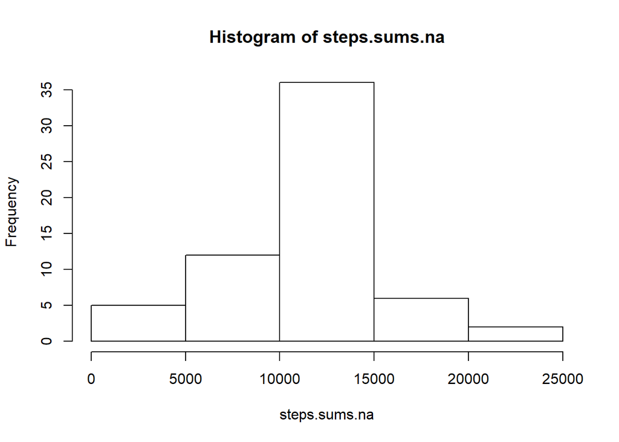

```r
hist(steps.sums.na)
```

```r
mean(steps.sums.na)
```

```
## [1] 10766.19
```

```r
median(steps.sums.na)
```

```
## [1] 10766.19
```

# 8) Comparison of average steps per interval across weekends and weekdays

The code below plots a time series comparison of the average number of steps in each time interval, considering weekends versus weekdays.

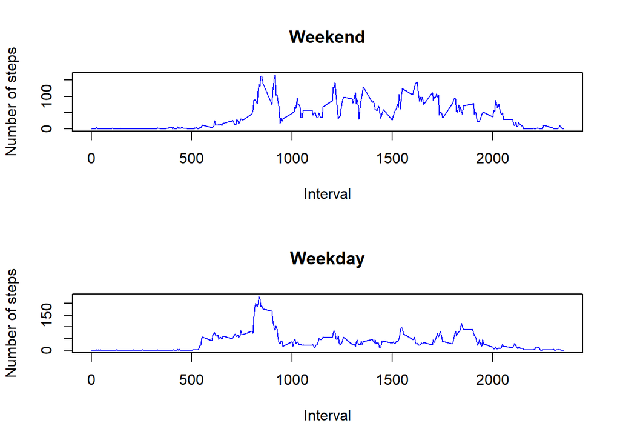

```r
weekday.vector <- weekdays(activity.data.na$date,abbreviate=TRUE)
weekday.vector[weekday.vector=="Mon"] <- "weekday"
weekday.vector[weekday.vector=="Tue"] <- "weekday"
weekday.vector[weekday.vector=="Wed"] <- "weekday"
weekday.vector[weekday.vector=="Thu"] <- "weekday"
weekday.vector[weekday.vector=="Fri"] <- "weekday"
weekday.vector[weekday.vector=="Sat"] <- "weekend"
weekday.vector[weekday.vector=="Sun"] <- "weekend"
activity.data.na$daytype <- weekday.vector

activity.data.na.weekday <- activity.data.na[activity.data.na$daytype=="weekday",]
activity.data.na.weekend <- activity.data.na[activity.data.na$daytype=="weekend",]

intervals.means.weekday <- tapply(activity.data.na.weekday$steps, activity.data.na.weekday$interval, FUN=average.na)
intervals.means.weekend <- tapply(activity.data.na.weekend$steps, activity.data.na.weekend$interval, FUN=average.na)

par(mfrow=c(2,1))
plot(intervals, intervals.means.weekend, type="l", col="blue", ylab="Number of steps", xlab="Interval", main="Weekend")
plot(intervals, intervals.means.weekday, type="l", col="blue",ylab="Number of steps", xlab="Interval", main="Weekday")
```